# R Notebook

## Bar Chart term

Bar chart are effective for visualizing and comparing data across different categories, here the height of each bar is proportional to the value or frequency it represents

## Drawing a bar chart

to draw a bar chart you will need only a categorical variable given to the x aesthetics

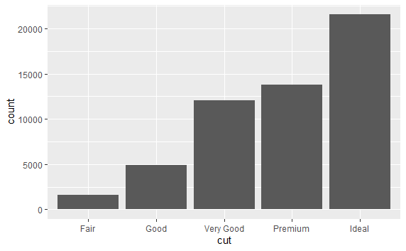

```r
diamonds |> ggplot(aes(x = cut)) + geom_bar()
```

## flipping the bar chart

to flip the bars, assign the categorical variable to y aesthetics

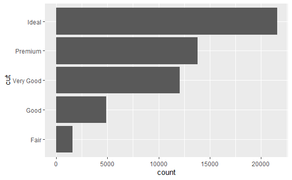

```r
diamonds |> ggplot(aes(y = cut)) + geom_bar()
```

or similarly

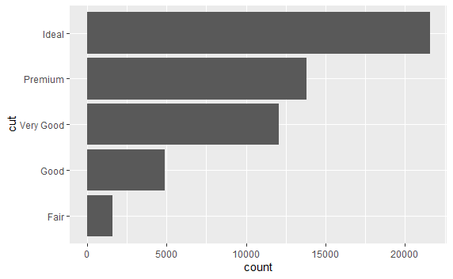

```r
diamonds |> ggplot(aes(x = cut)) + geom_bar() + coord_flip()
```

## Adding colours(path)

to add color to bar chart path drawn add the color argument **NOT THE AESTHETICS FUNCTION COLOR**

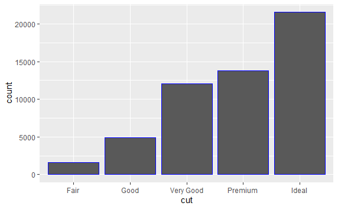

```r
diamonds |> ggplot(aes(x = cut)) + geom_bar(color = "blue")
```

## Adding colours(fill)

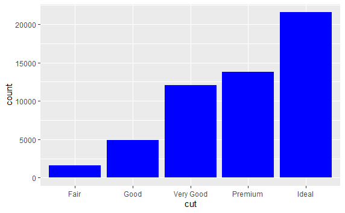

```r
diamonds |> ggplot(aes(x = cut)) + geom_bar(fill = "blue")
```

## Adding unique Colour

to add unique color to each bar, use the fill argument **IN THE AESTHETICS FUNCTION** mapping it to a variable

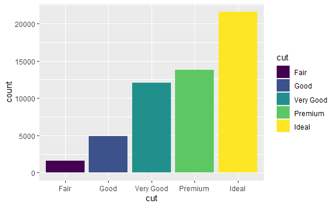

```r
diamonds |> ggplot(aes(x = cut)) + geom_bar(mapping = aes(fill = cut))
```

## Adding unique Colour(specific)

to add unique color to a specific bar, use scale_fill_manual function to manually add the colors, name the colors for more specificity **Note** you will need to add fill in the aesthetics for things to work, map the fill in the aesthetics to a variable

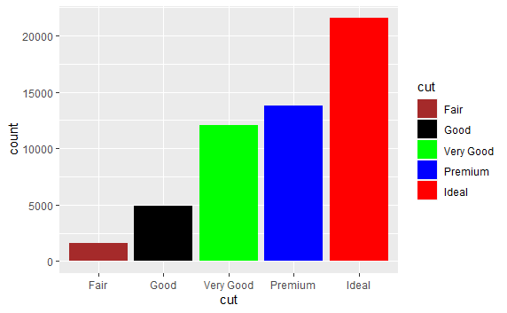

```r
bar_colors <- c("red","blue","black","green","brown")
names(bar_colors) <- unique(diamonds$cut)
diamonds |> ggplot(aes(x = cut, fill = cut)) + geom_bar() + scale_fill_manual(values = bar_colors)
```

## Component(stacked) bar chart

showing proportion of groups within a group in a group this displays the total value while also showing the contribution of each individual subcategories.

## Adding stacked bar chart

after adding a normal bar chart add the fill to another different variable which is the groups within a particular, and set the position argument **NOT THE AES FUNCTION** and set it to position_stack() we can use in sense of a progress bar

if you flip the coordinate set reverse to true inside the postion_stack()

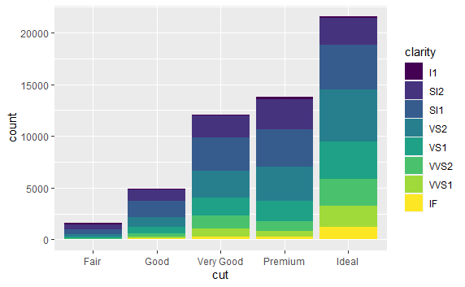

```r
diamonds |> ggplot(aes(x = cut)) + geom_bar(mapping = aes(fill = clarity), position = position_stack())
```

## Adding multiple barchart

for multiple bar chart change the above bar chart(stacked), change the position argument to position_dodge

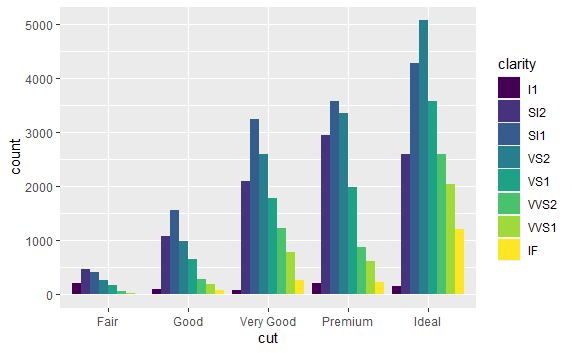

```r
diamonds |> ggplot(aes(x = cut)) + geom_bar(mapping = aes(fill = clarity), position = position_dodge())
```